# Reproducible Research: Principles, Practices, and Tools for Generating Reproducible Statistical Analyses and Reports

CSTAT webinar series on Responsible and Ethical Conduct of Research, East Lansing, MI

Steven J. Pierce

Michigan State University, Center for Statistical Training and Consulting

2025-10-02

## Outline

- What do you mean by reproducible?
- Why should we aim for reproducibility?
- How do we achieve reproducibility?
- Demonstration

# What do you mean by reproducible?

Let’s define some concepts.

## Reproducible Research (RR)

… is achieved when investigators *share all the materials required to exactly recreate the findings* so that others can verify them or conduct alternative analyses.

## Statistical Results Can Be:

Repeatable

- Original analyst
- Original data

Reproducible

- New analyst
- Original data

Replicable

- New analyst
- New data

**Important**

Achieving repeatability is a stepping stone toward reproducibility!

## RR is a Product

[figure not shown]

RR is a product of *how we work*, not which methods we use.

# Why aim for reproducibility?

Several forces are promoting and enabling the push toward it.

## Methods Matter!

Irreproducible < Reproducible < Replicated

**Important**

Reproducibility is an attainable minimum standard for science<sup>[1]</sup>.

## Funders Value RR

Data sharing and reproducibility initiatives

[figure not shown]

[figure not shown]

[figure not shown]

- https://grants.nih.gov/policy-and-compliance/policy-topics/sharing-policies/dms
- https://grants.nih.gov/policy-and-compliance/policy-topics/reproducibility
- https://www.nsf.gov/funding/data-management-plan
- https://ies.ed.gov/blogs/research/post/companion-guidelines-on-replication-and-reproducibility-in-education-research

## Scientific Norms

- Open science (https://www.cos.io/open-science)
- Pre-registered methods<sup>[2–4]</sup>
- Reporting guidelines<sup>[5–8]</sup>
- Publishing raw data<sup>[9,10]</sup>
- Journal & publisher policies<sup>[3,9–12]</sup>
- Institutional policies

## Publishing Technology

[figure not shown]

## Career Benefits of RR

- Motivation to focus on quality
- Become more efficient
- Create more products
- Easier to get published
- Get cited more often
- Build your reputation

## Questions/Brief Discussion (1)

# How do we achieve reproducibility?

Understand the criteria, then apply principles, practices, & tools.

## Criteria for Reproducbility <sup>[1]</sup>

- Data
- Methods
- Documentation
- Distribution

## Materials Required to Recreate Findings

Table 1

| Materials | Findings |
| --- | --- |
| Manuals & procedures | Statistics |
| Instruments & scoring rules | Coefficients & p-values |
| Codebooks | Confidence intervals |
| Methods applied | Effect sizes |
| Data mgt decisions | Model fit indices |
| Data files | Figures |
| Software & analysis scripts | Tables |

## Principles for Achieving Reproducibility

- Collaboration
- Organization
- Automation
- Preservation
- Integration
- Separation

## Workflow Woes

- Use GUI, menus, & dialog boxes to do tasks
- Manually updating data files
- Version control through saving to new file names
- Disorganized folders & files
- No audit trail
- Copy & paste output from stats software to word processor
- Fixing mistakes took lots of time

## Spock

“Captain, you’re asking me to work with equipment which is hardly very far ahead of stone knives and bearskins.”

*Star Trek (1966) - S01E28 The City on the Edge of Forever*

## Free, Open Source Software Tools for Reproducible Research

- [R](https://www.r-project.org/)<sup>[13]</sup>, for statistical computing
- [RStudio Desktop](https://posit.co/download/rstudio-desktop/)<sup>[14]</sup>, an editor
- [Quarto](https://quarto.org)<sup>[15]</sup>, for dynamic documents
- [TinyTeX](https://yihui.org/tinytex/), for nice PDF output
- [Git](https://git-scm.com/)<sup>[16]</sup>, for version control
- [GitHub.com](https://github.com), for sharing & collaborating on code

## Dynamic Documents Via Quarto + R

[figure not shown]

## A Research Compendium …

organizes digital files so others can review or use them to reproduce results, or do new analyses.<sup>[17]</sup> It should:

- Use prevailing conventions to organize the project
- Separate data, method, & output but show how they are related
- Specify the software used in the original analysis

## R Packages are …

folders of digital files designed for sharing code & help documentation.<sup>[18]</sup>

- Organize files into a conventional structure
- Can contain data, meta-data, & other documentation
- Can contain dynamic documents & rendered output

**Tip**

Use an R package for a research compendium!<sup>[17]</sup>

## RStudio Projects are …

folders of files that:

- Keep files for an analysis project together
- Can have subfolders for organizing files
- Serve as R working directories w/ workspace & history
- Store settings in an RStudio project file (`*.Rproj`)

**Tip**

Turn your compendium into an [RStudio project](https://docs.posit.co/ide/user/ide/guide/code/projects.html)!

## Git Repositories are …

folders of files tracked by Git for version control.<sup>[16,19,20]</sup>

- Preserve a history of changes to each tracked file
- Allow recovering a file’s prior state from the history
- Can be local or remote (hosted on a server)
- Can be private or public

**Tip**

Put your research compendium in a Git repository!

## GitHub

[figure not shown]

## Quarto Projects are …

folders of files that allow:

- Rendering some or all dynamic documents
- Sharing a configuration file across documents
- Redirecting output to another folder
- Freezing rendered output unless the code has changed

**Tip**

Turn a subfolder of your compendium into a [Quarto project](https://quarto.org/docs/projects/quarto-projects.html)!

## Example Folder Structure

```
MyStudy/            [Compendium, Git repository, R package, RStudio project]
  - .git/           [Hidden folder, holds Git tracking database]
  - .Rproj.user/    [Hidden folder, holds RStudio temporary files]
  - data/           [Holds R data files created by scripts]
  - man/            [Holds R help files for package & custom functions]
  - R/              [Holds R scripts w/ custom functions]
  - scripts/        [Quarto project, holds dynamic documents]
    - extdata/      [Holds external data files to be imported]
    - output/       [Holds rendered output]
  - .gitignore      [Tells Git what to omit from tracking]
  - DESCRIPTION     [R package meta-data]
  - MyProject.Rproj [RStudio project file & settings]
  - NEWS.md         [News for users re: changes to package]
  - README.Rmd      [Dynamic document, creates README.md]
  - README.md       [Rendered output, R package documentation]
```

## Questions/Brief Discussion (2)

## Collaboration Stakeholders

- Your future self
- Your team
- Peer reviewers
- Your audience

## Organization Tips

- Add documentation!
- Use file naming conventions to links scripts & output
- Use data flow diagrams to show relations between files
- Use a primary rendering script to run other scripts

## Example Data Flow Diagram

[figure not shown]

## Automation Tips

- Use scripts instead of GUIs
- Write [self-contained scripts](https://www.tidyverse.org/blog/2017/12/workflow-vs-script/)
- Render entire script frequently
- Computers are patient
- Computers are idiots

## Preservation Tips

What should you preserve?

- Data and meta-data
- Methodology decisions & rationales
- Scripts (data cleaning, management, & analysis)
- Version histories of data, code, & output
- Software environment & versions used

## Integration Tips

- Attach meta-data directly to data
- Use Quarto to integrate narrative text & code
- Add R functions & help files to your compendium
- Include citations & reference lists

## Separation Tips

Table 2

| Separate This |  | From That |
| --- | --- | --- |
| Raw Data | \| | Cleaned Data |
| Code | \| | Data |
| Code | \| | Output |
| Data Management | \| | Data Analysis |
| Draft Outputs | \| | Final Deliverables |
| Current Files | \| | Version History |

## Quarto Scripts: Anatomy

- Plain text files with names ending in `.qmd`
- Use [markdown syntax](https://quarto.org/docs/authoring/markdown-basics.html) to format rendered output
- YAML header contains metadata, options, & parameters
- Body contains the main content
- Headings
- Text w/ formatting
- Bulleted lists
- In-text citations
- Callout boxes
- Code
- Equations
- Tables & figures
- Cross-references
- Reference list

## Quarto Scripts: Code

- [Inline code](https://quarto.org/docs/computations/inline-code.html) lets you insert dynamic text or numbers into sentences.

  ```
  The mean of x is `{r} mean(x)`.
  ```

- [Code chunks](https://quarto.org/docs/computations/r.html) allow you to do larger computations and insert more complex results.

  ````markdown
  ```{r}
  #| label fig-example

  ggplot(mydata, aes(distance, time)) +
    xlab("Race Distance") +
    ylab("Running Time (minutes)")
  ```
  ````

## MyStudy Demonstration Files

Let’s take a look at actual dynamic documents!

- `MyStudy_Report.qmd`
- `output/MyStudy_Report.html`

## MyStudy_Report.qmd YAML Header (1)

[figure not shown]

## MyStudy_Report.html (1)

[figure not shown]

## MyStudy_Report.qmd YAML Header (2)

[figure not shown]

## MyStudy_Report.qmd YAML Header (3)

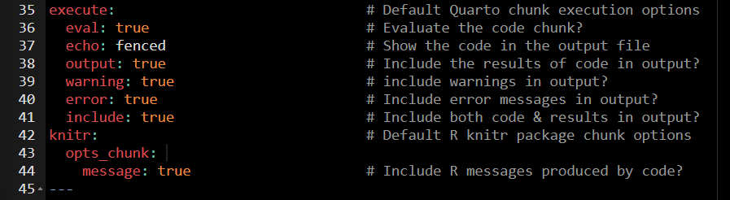

## MyStudy_Report.html (2)

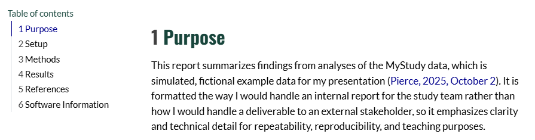

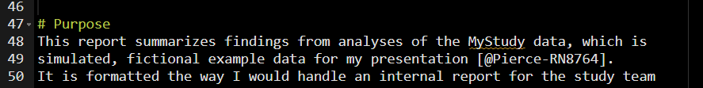

Lines from MyStudy_Report.qmd

## MyStudy_Report.html (3)

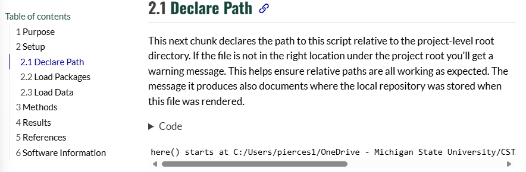

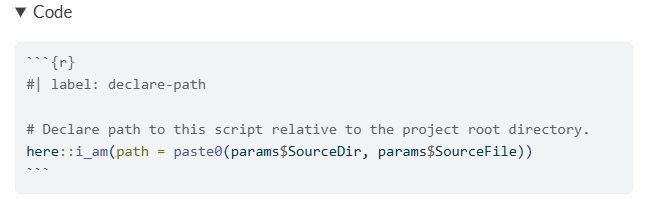

## MyStudy_Report.qmd YAML Header (4)

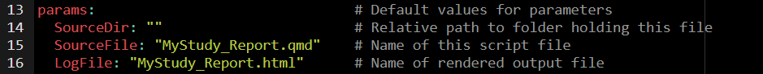

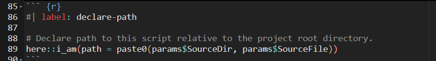

A code chunk from the body of the report

## MyStudy_Report.html (4)

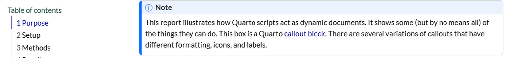

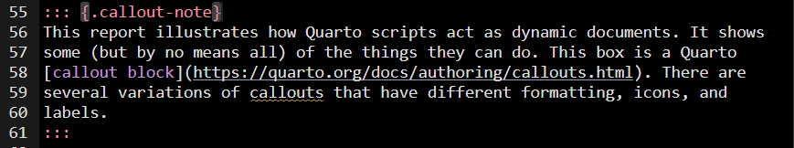

Lines from MyStudy_Report.qmd

## MyStudy_Report.html (5)

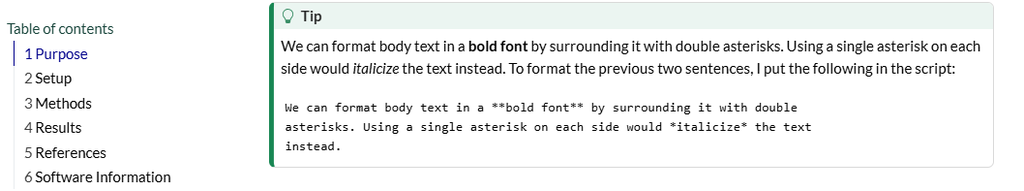

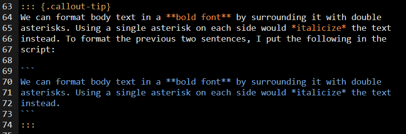

Lines from MyStudy_Report.qmd

## MyStudy_Report.html (6)

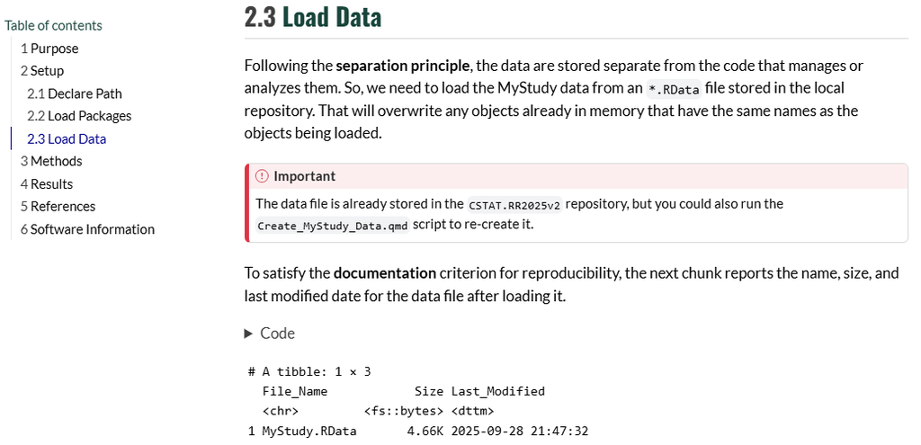

## MyStudy_Report.html (7)

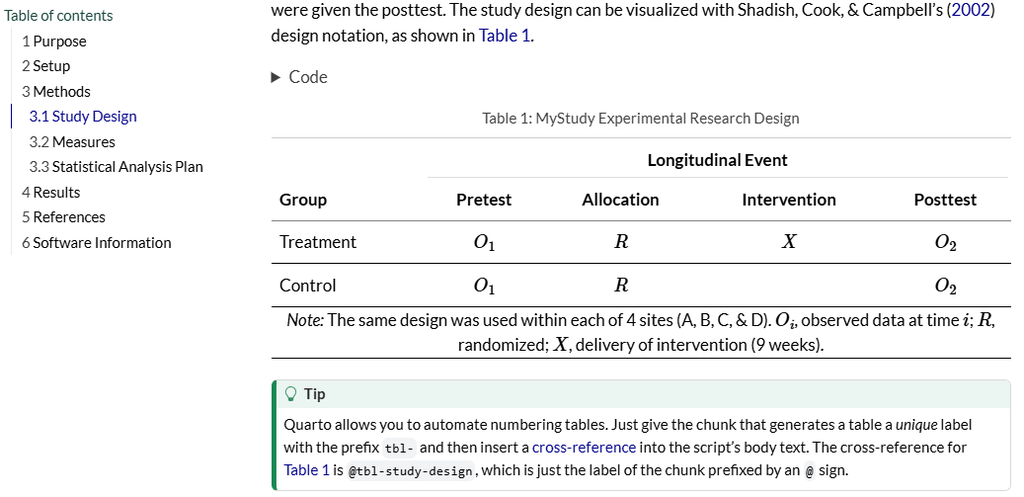

## MyStudy_Report.html (8)

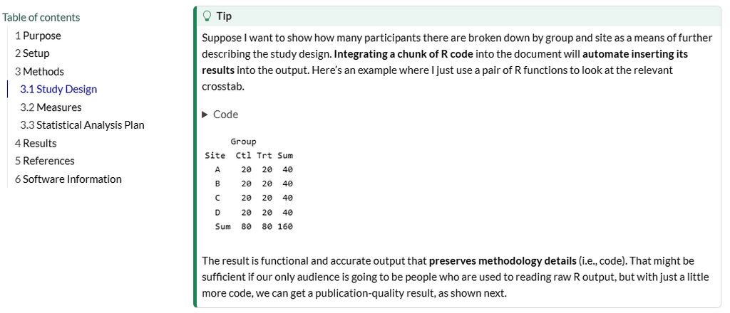

## MyStudy_Report.html (9)

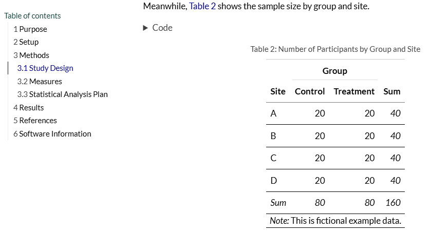

## MyStudy_Report.html (10)

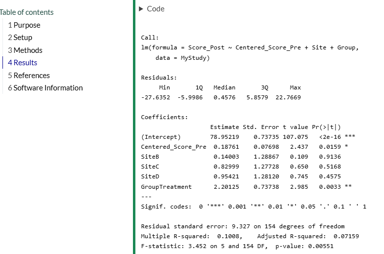

## MyStudy_Report.html (11)

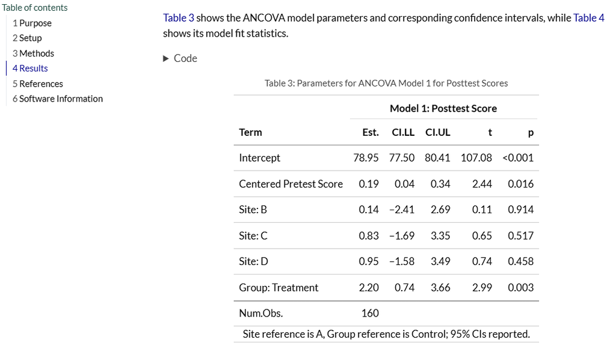

## MyStudy_Report.html (12)

[figure not shown]

## MyStudy_Report.html (13)

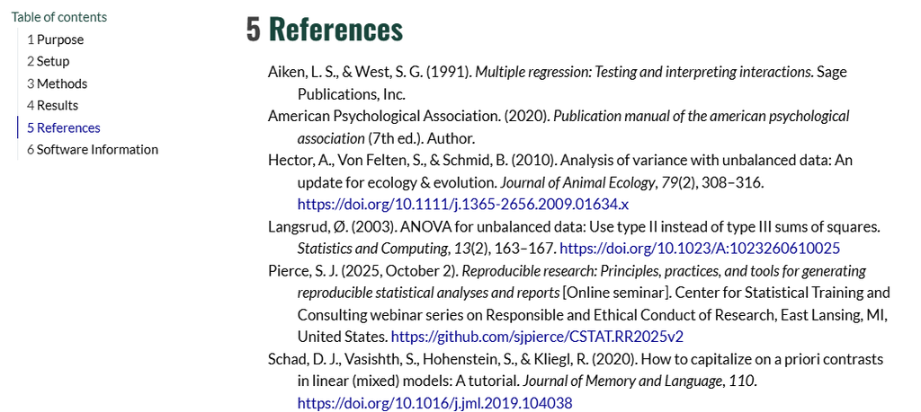

## MyStudy_Report.html (14)

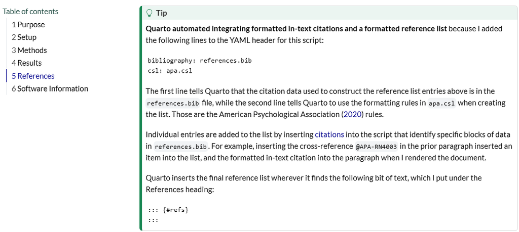

## MyStudy_Report.html (15)

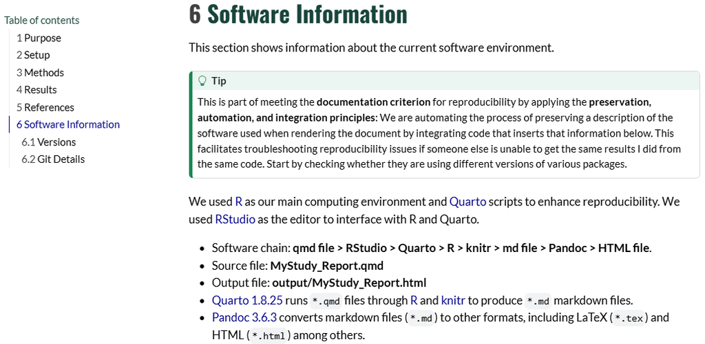

## Bonus Resources

- R for non-programmers: A guide for social scientists<sup>[21]</sup>
- What they forgot to teach you about R<sup>[22]</sup>
- [RStudio IDE user guide](https://docs.posit.co/ide/user/)
- [Using RStudio projects](https://support.posit.co/hc/en-us/articles/200526207-Using-RStudio-Projects)
- R packages: Organize, test, document, and share your code<sup>[18]</sup>
- Happy Git and GitHub for the useR<sup>[23]</sup>
- [Tutorial: Hello, Quarto](https://quarto.org/docs/get-started/hello/rstudio.html)
- Quarto for scientists<sup>[24]</sup>

## References

1. Peng, R. D., Dominici, F., & Zeger, S. L. (2006). Reproducible epidemiologic research. *American Journal of Epidemiology*, *163*(9), 783–789. https://doi.org/10.1093/aje/kwj093

2. Bosnjak, M., Fiebach, C. J., Mellor, D., Mueller, S., O’Connor, D. B., Oswald, F. L., & Sokol, R. I. (2022). A template for preregistration of quantitative research in psychology: Report of the Joint Psychological Societies Preregistration Task Force. *American Psychologist*, *77*(4), 602–615. https://doi.org/10.1037/amp0000879

3. DeCoster, J., Sparks, E. A., Sparks, J. C., Sparks, G. G., & Sparks, C. W. (2015). Opportunistic biases: Their origins, effects, and an integrated solution. *American Psychologist*, *70*(6), 499–514. https://doi.org/10.1037/a0039191

4. Moore, D. A. (2016). Preregister if you want to. *American Psychologist*, *71*(3), 238–239. https://doi.org/10.1037/a0040195

5. Appelbaum, M., Cooper, H., Kline, R. B., Mayo-Wilson, E., Nezu, A. M., & Rao, S. M. (2018). Journal article reporting standards for quantitative research in psychology: The APA publications and communications board task force report. *American Psychologist*, *73*(1), 3–25. https://doi.org/10.1037/amp0000191

6. Moher, D., Hopewell, S., Schulz, K. F., Montori, V., Gøtzsche, P. C., Devereaux, P. J., Elbourne, D., Egger, M., & Altman, D. G. (2010). CONSORT 2010 explanation and elaboration: Updated guidelines for reporting parallel group randomized trials. *Journal of Clinical Epidemiology*, *63*(8), e1–e37. https://doi.org/10.1016/j.jclinepi.2010.03.004

7. Schulz, K. F., Altman, D. G., & Moher, D. (2010). CONSORT 2010 statement: Updated guidelines for reporting parallel group randomised trials. *Journal of Clinical Epidemiology*, *63*(8), 834–840. https://doi.org/10.1016/j.jclinepi.2010.02.005

8. von Elm, E., Altman, D. G., Egger, M., Pocock, S. J., Gøtzsche, P. C., & Vandenbroucke, J. P. (2007). The strengthening the reporting of observational studies in epidemiology (STROBE) statement: Guidelines for reporting observational studies. *PLoS Medicine*, *4*(10), e296. https://doi.org/10.1371/journal.pmed.0040296

9. Hrynaszkiewicz, I., & Altman, D. G. (2009). Towards agreement on best practice for publishing raw clinical trial data. *Trials*, *10*(1), 17. https://doi.org/10.1186/1745-6215-10-17

10. Hrynaszkiewicz, I., Norton, M. L., Vickers, A. J., & Altman, D. G. (2010). Preparing raw clinical data for publication: Guidance for journal editors, authors, and peer reviewers. *Trials*, *11*(1), 9. https://doi.org/10.1186/1745-6215-11-9

11. Laine, C., Goodman, S. N., Griswold, M. E., & Sox, H. C. (2007). Reproducible research: Moving toward research the public can really trust. *Annals of Internal Medicine*, *146*(6), 450–453. https://doi.org/10.7326/0003-4819-146-6-200703200-00154

12. Peng, R. D. (2009). Reproducible research and biostatistics. *Biostatistics*, *10*(3), 405–408. https://doi.org/10.1093/biostatistics/kxp014

13. R Development Core Team. (2025). *R: A language and environment for statistical computing* (Version 4.5.1) [Computer Program]. R Foundation for Statistical Computing. https://www.R-project.org

14. RStudio Team. (2025). *RStudio Desktop: Integrated development environment for R* (Version 2025.09.0+387) [Computer Program]. Posit Software, PBC. https://posit.co

15. Allaire, J. J., Dervieux, C., Scheidegger, C., Teague, C., & Xie, Y. (2025). *Quarto* (Version 1.8.25) [Computer Program]. Posit Software, PBC. https://quarto.org

16. Torvalds, L., Hamano, J. C., & other contributors to the Git Project. (2025). *Git for Windows* (Version 2.51.0(2)) [Computer Program]. Software Freedom Conservancy. https://git-scm.com

17. Marwick, B., Boettiger, C., & Mullen, L. (2018). Packaging data analytical work reproducibly using r (and friends). *The American Statistician*, *72*(1), 80–88. https://doi.org/10.1080/00031305.2017.1375986

18. Wickham, H., & Bryan, J. (2021). *R packages: Organize, test, document, and share your code*. O’Reilly Media. https://r-pkgs.org

19. Bryan, J. (2018). Excuse me, do you have a moment to talk about version control? *The American Statistician*, *72*(1), 20–27. https://doi.org/10.1080/00031305.2017.1399928

20. Chacon, S., & Straub, B. (2014). *Pro Git*. Apress Media. https://git-scm.com/book/en/v2

21. Dauber, D. (2025). *R for non-programmers: A guide for social scientists* [Electronic Book]. https://r4np.com/

22. Bryan, J., Hester, J., Pileggi, S., & Aja, E. D. (2024). *What they forgot to teach you about R* [Electronic Book]. https://rstats.wtf

23. Bryan, J., TAs, T. S. 545., & Hester, J. (n.d.). *Happy Git and GitHub for the useR* [Electronic Book]. https://happygitwithr.com

24. Tierney, N. (2025). *Quarto for scientists* [Electronic Book]. https://qmd4sci.njtierney.com/

# Questions & Discussion Time

Thank you for attending!